# Final Project

- Show All Code
- Hide All Code
- View Source

Author

Owen Bachhuber, Melanie Mitton, Magdalene Lo, Corban Lethcoe

## Introduction

### Motivation

As reported by the [New York Times](https://www.nytimes.com/2023/11/06/health/tuberculosis-tb-treatment-vaccine-diagnosis.html), tuberculosis (TB) is again the world’s leading infectious disease killer as of November 2023, after being briefly surpassed by COVID-19. The World Health Organization reports that nearly 40 percent of people who are living with TB are untreated and undiagnosed. Despite being a preventable and curable disease, 1.36 million people died from tuberculosis in 2022.

This project aims to better contextualize the relationship between a government spending and tuberculosis on a country-by-country basis. We hypothesize that the countries that spend more on healthcare per person also see fewer deaths from tuberculosis.

### Source Data

Two data sets were chosen for this analysis: 1) the estimated numbers of deaths caused by TB (all forms) among 100,000 residents during the given year from 2000 - 2015 sorted by country, and 2) the average health expenditures per person paid by government entities from 1995 - 2010 expressed in US dollars using the average exchange rate.

The data sets were joined by country and only complete observations from 2000 - 2010 were included. The TB deaths data included 216 countries while the government healthcare spending data included 192 countries. Our combined dataset included 192 countries.

```r
library(tidyverse)
library(here)
library(ggplot2)
library(gridExtra)
library(gganimate)
library(gifski)
library(kableExtra)
library(broom)
library(patchwork)


tb_deaths_long <- read_csv(here("all_forms_of_tb_deaths_per_100000_estimated.csv"))
gov_health_spending_long <- read_csv(here("government_health_spending_per_person_us.csv"))

# Count the number of countries in the source data
tb_deaths_long <- tb_deaths_long |>
  mutate(country = as.factor(country))
  #       length(unique(tb_deaths_long$country))

gov_health_spending_long <- gov_health_spending_long |>
  mutate(country = as.factor(country))
  #       length(unique(gov_health_spending_long$country))

# Pivot the Tuberculosis Deaths Data
tb_deaths_long <- tb_deaths_long |>
  pivot_longer(cols = -country, names_to = "year", values_to = "deaths_per_100k", names_prefix = "X") |>
  mutate(year = as.integer(year)) |>
  drop_na()

# Pivot the Government Health Spending Data
gov_health_spending_long <- gov_health_spending_long |>
  pivot_longer(cols = -country, names_to = "year", values_to = "gov_health_spending_usd", names_prefix = "X") |>
  mutate(year = as.integer(year)) |>
  drop_na()

# Join the cleaned, long-format datasets
combined_dataset_long_cleaned <- inner_join(tb_deaths_long, gov_health_spending_long, by = c("country", "year")) |>
  mutate(country = as.factor(country))

# Remove any remaining rows with NAs
combined_dataset_long_cleaned <- drop_na(combined_dataset_long_cleaned)

# Write the cleaned, combined dataset to a CSV file
write_csv(combined_dataset_long_cleaned, here("combined_dataset_long_cleaned.csv"))

# Count the number of countries in the final dataset
#length(unique(combined_dataset_long_cleaned$country))
```

## Data Visualization

To examine how the relationship between our two variables of interest changed over time, we created an animated plot that shows TB deaths per 100k vs. government spending per person in USD for every country in every year of the study (2000 - 2010).

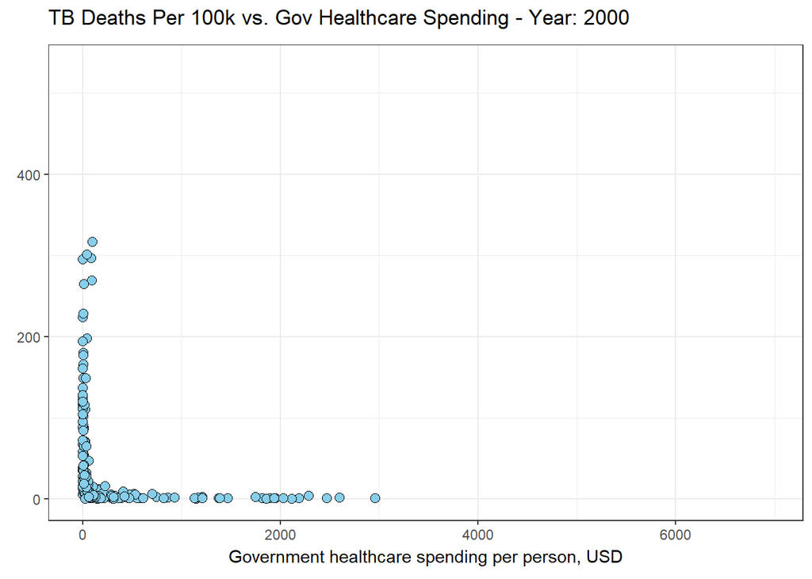

```r
plot <- combined_dataset_long_cleaned |>
  ggplot(aes(
    x = gov_health_spending_usd,
    y = deaths_per_100k
  )) +
  geom_point(shape = 21,
             size = 2.5,
             color = "black",
             fill = "skyblue") +
  labs(title = "TB Deaths Per 100k vs. Gov Healthcare Spending - Year: {frame_time}",
       y = "",
       x = "Government healthcare spending per person, USD") +
  transition_time(year) +
  ease_aes('linear') +
  theme(aspect.ratio = 1)+
  theme_bw()

# Create the animation object
anim <- animate(plot,nframes = 10 , duration = 20, renderer=gifski_renderer())

# Save the animation
anim_save("Animation_trials/Generated_animations/animation.gif",animation = anim)
anim
```

Over time, the amount of government spending per person increased on average. The relationship between deaths per 100k and government spending displays an exponential decay overtime, suggesting that as government spending increases, the number of deaths per 100k decreases. To confirm this inference, we created density plots of deaths per 100k and government spending per person to show how the proportional distribution changes overtime.

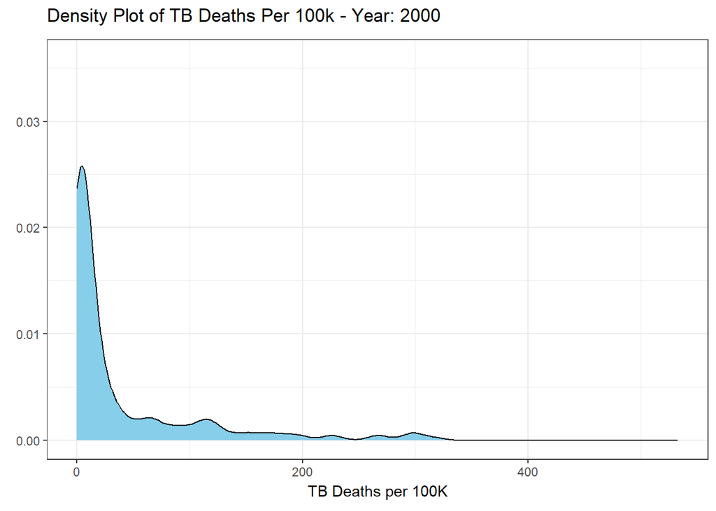

```r
## Density plot of deaths per 100k
plot_2 <- combined_dataset_long_cleaned |>
  ggplot(aes(x = deaths_per_100k)) +
  geom_density(fill = "skyblue", color = "black") +
  labs(title = "Density Plot of TB Deaths Per 100k - Year: {frame_time}") +
  labs(y = "",
       x = "TB Deaths per 100K")+
  transition_time(year) +
  ease_aes('linear') +
  theme(aspect.ratio = 1)+
  theme_bw()

anim_2 <- animate(plot_2,nframes = 10 , duration = 20, renderer=gifski_renderer())

# Density plot of gov spending.
plot_3 <- combined_dataset_long_cleaned |>
  ggplot(aes(x = gov_health_spending_usd)) +
  geom_density(fill = "skyblue", color = "black") +
  labs(title = "Density Plot of Gov Spending Per Person in USD - Year: {frame_time}") +
   labs(y = "",
       x = "Government healthcare spending per person, USD")+
  transition_time(year) +
  ease_aes('linear') +
  theme(aspect.ratio = 1)+
  theme_bw()

anim_3 <- animate(plot_3,nframes = 10 , duration = 20, renderer=gifski_renderer())
anim_2
```

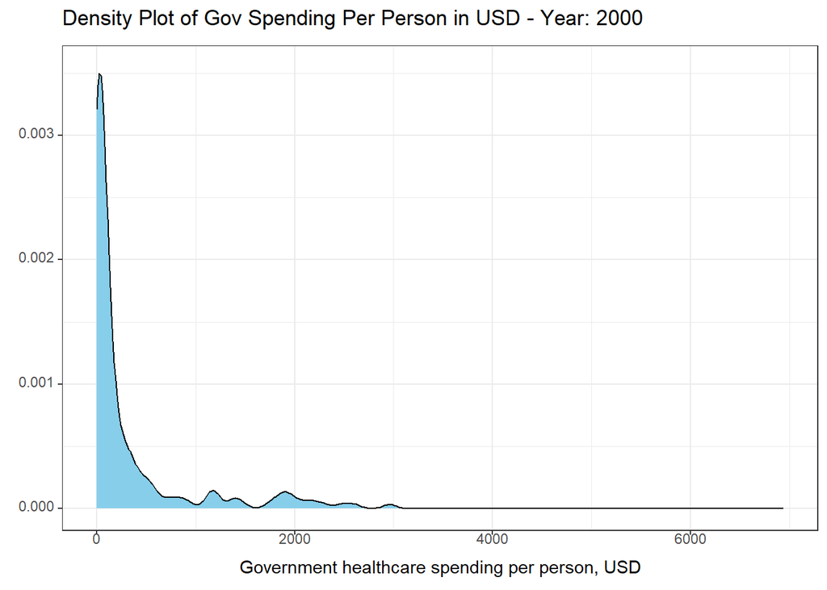

```r
anim_3
```

From these plots, it becomes clearer that as government spending increased over time, the number of TB deaths per 100k decreased.

## Linear Regression

To further explore the relationship between government spending and deaths caused by TB, we took the average government spending and average deaths per 100k for all recorded years for each country and fit a linear regression to the dataset. Each point represents one country.

[figure not shown]

```r
combined_dataset_long_cleaned |>
  group_by(country) |>
  summarise(mean_deaths = mean(deaths_per_100k),
            mean_spending = mean(gov_health_spending_usd)) |>
  ggplot(aes(x = mean_deaths, y = mean_spending)) +
  geom_point(shape = 21,
             size = 2.5,
             color = "black",
             fill = "skyblue") +
  geom_smooth(method = "lm",
              color = "black") +
  xlab("Average Government Healthcare Spending per Person, USD") +
  ylab("") +
  labs(title = "Linear Regression of Average Government Healthcare Spending\nper Person on Average TB Deaths per Country, 2000–2010",
       subtitle = "\nAverage TB Deaths per 100,000"
       )+
  theme_bw()
```

#### Modeled Equation

```r
combined_dataset_long_av <- combined_dataset_long_cleaned |>
  group_by(country) |>
  summarise(av_deaths_per_100k = mean(deaths_per_100k),
            av_gov_health_spending_usd = mean(gov_health_spending_usd)) |>
  ungroup()

combined_dataset_lm <- lm(av_deaths_per_100k ~ av_gov_health_spending_usd ,
                          data = combined_dataset_long_av)

broom::tidy(combined_dataset_lm) |>
  kable() |>
  kable_styling(bootstrap_options = "striped",
                position = "center")
```

| term | estimate | std.error | statistic | p.value |
| --- | --- | --- | --- | --- |
| (Intercept) | 44.5173933 | 5.4090157 | 8.230221 | 0.0000000 |
| av_gov_health_spending_usd | -0.0171719 | 0.0049035 | -3.502011 | 0.0005755 |

$\text{Average TB Deaths per 100k} = 44.52 - 0.017 \times \text{Average Government Health Spending per Person (USD)}$

#### Interpretation

There is a negative correlation between TB deaths per 100k and government healthcare spending per person. Our model suggests that for every $1000(USD) spent by a government on healthcare, on average, 17 people per 100,000 are prevented from dying of TB. It also suggests that if a government does not spend anything per person on healthcare, 44 people out of 100,000 will die of TB per year on average. However, the relationship between government healthcare spending and TB deaths is not linear and is more similar to a hyperbolic or negative exponential relationship. There is a large amount of variation in average number of TB deaths between countries that spend very little per person on healthcare, and many countries see very few deaths due to TB despite spending very much or little per person on healthcare.

When comparing the variance in the response variable and the variance of the fitted data (below), only 6% of the variance in average deaths per 100k is explained by government spending per person. The remaining variance (94%) is not explained by the linear model. Considering the small P-value, however, government healthcare spending appears to be a small but significant factor affecting TB deaths. Other factors may include the cost and accessibility of TB screening and drugs, the ratio of healthcare workers to citizens, how often TB drug regimens can be completed, the rate of TB transmission, and many more.

```r
broom::augment(combined_dataset_lm) |>
  select(1,3,4) |>
  map(.f = ~ var(.x)) |>
  as.tibble() |>
  rename("Variance of average deaths per 100k" = av_deaths_per_100k,
         "Variance of fitted data" = .fitted,
         "Variance of residuals" = .resid) |>
  kable() |>
  kable_styling(bootstrap_options = "striped",
                position = "center")
```

| Variance of average deaths per 100k | Variance of fitted data | Variance of residuals |
| --- | --- | --- |
| 4605.323 | 279.2392 | 4326.084 |

## Predictive Checks

To test how well the linear model fits our data, we created simulated data from the linear model. If these data are similar to the actual data gathered by the WHO, then we can be confident in our linear model. Below is our actual TB deaths data (left) and simulated TB deaths data (right).

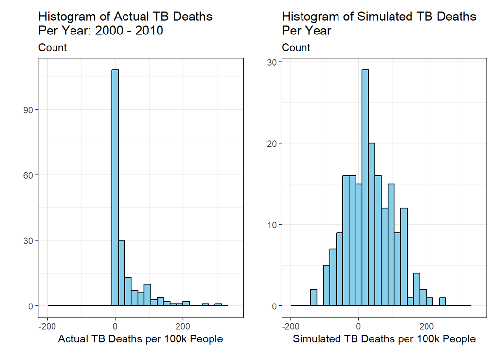

```r
# Obtain predictions
tb_predict <- predict(combined_dataset_lm)
#head(tb_predict)

# Calculate residual standard error
tb_sigma <- sigma(combined_dataset_lm)


# Create a function for noise
noise <- function(x, mean = 0, sd){
  x + rnorm(length(x),
            mean,
            sd)
}

# Generate a fake dataset
sim_response <- tibble(sim_deaths_per_100k = noise(tb_predict,
                                           sd = tb_sigma)
                   )
# Make a histogram comparing the actual and simulated data
obs_p <- combined_dataset_long_av |>
  ggplot(aes(x = av_deaths_per_100k)) +
  geom_histogram(color = "black",
                 fill = "skyblue"
                 ) +
  labs(title = "Histogram of Actual TB Deaths\nPer Year: 2000 - 2010",
       x = "Actual TB Deaths per 100k People",
       y = "",
       subtitle = "Count") +
  xlim(-200, 350) +
  theme_bw()

new_p <- sim_response |>
  ggplot(aes(x = sim_deaths_per_100k)) +
  geom_histogram(color = "black",
                 fill = "skyblue"
                 ) +
  labs(title = "Histogram of Simulated TB Deaths\nPer Year",
       x = "Simulated TB Deaths per 100k People",
       y = "",
       subtitle = "Count") +
  xlim(-200, 350) +
  theme_bw()


obs_p + new_p
```

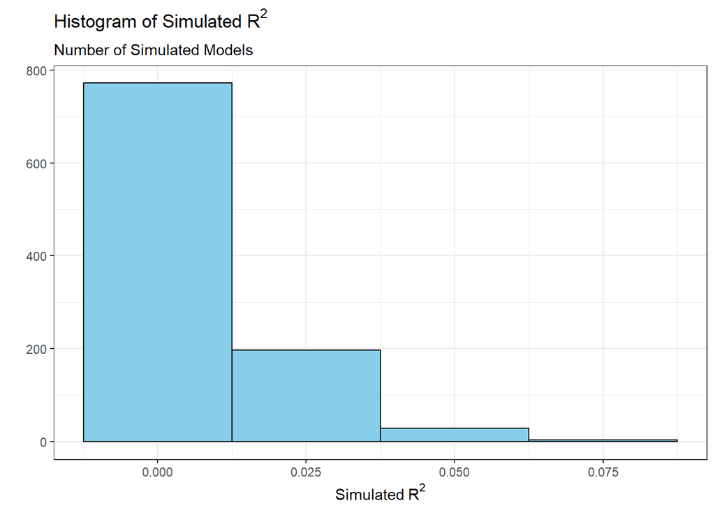

```r
nsims <- 1000
sims <- map_dfc(.x = 1:nsims,
                .f = ~ tibble(sim = noise(tb_predict,
                                          sd = tb_sigma)
                              )
                )

colnames(sims) <- colnames(sims) |>
  str_replace(pattern = "\\.\\.\\.",
                  replace = "_")

sims <- combined_dataset_long_av |>
  filter(!is.na(av_deaths_per_100k),
         !is.na(av_gov_health_spending_usd)) |>
  select(av_deaths_per_100k) |>
  bind_cols(sims)

sim_r_sq <- sims |>
  map(~ lm(av_deaths_per_100k ~ .x, data = sims)) |>
  map(glance) |>
  map_dbl(~ .x$r.squared)

sim_r_sq <- sim_r_sq[names(sim_r_sq) != "av_deaths_per_100k"]

tibble(sims = sim_r_sq) |>
  ggplot(aes(x = sims)) +
  geom_histogram(binwidth = 0.025,
                 color = "black",
                 fill = "skyblue") +
  labs(title = "Histogram of Simulated"~ R^2,
        x = expression("Simulated"~ R^2),
       y = "",
       subtitle = "Number of Simulated Models") +
  theme_bw()
```

## Conclusion

When analyzing the outcomes of infectious disease, many economic, social, and political factors may affect how deadly a disease can be. In the case of tuberculosis, over 80% of cases and deaths occur in low- and middle-income countries, and 50% of patients and their households face costs that are >20% of their income [@WHO_Tuberculosis_2023]. This analysis of the effect of government healthcare spending per person on TB deaths shows that increased average spending is a significant factor in decreasing TB deaths. However, it is only one small factor in this non-linear relationship. Per the World Health Organization, progress needs to be made across TB prevention and care; financing care; TB research, information translation, and information dissemination; and much more to end TB [@WHO_Tuberculosis_2023].

## Sources

Govt. health spending per person (US$): World Health Organization through [gapminder.org](https://www.gapminder.org/data/)

Nolen, S. (2023, November 6) Ending TB Is Within Reach — So Why Are Millions Still Dying? *The New York Times*. https://www.nytimes.com/2023/11/06/health/tuberculosis-tb-treatment-vaccine-diagnosis.html

TB deaths per 100,000, estimated, all forms of TB: World Health Organization through [gapminder.org](https://www.gapminder.org/data/)

World Health Organization (2023, November 7) Tuberculosis. *World Health Organization.* https://www.who.int/news-room/fact-sheets/detail/tuberculosis